# Reproducible Research: Peer Assessment 1

## Loading and preprocessing the data

The below code loads the libraries for `dplyr` and `xtable`. Then loads the data file and converts it into dplyr dataframe.

```r
library(dplyr)
library(xtable)

data<-read.csv("activity.csv", header=TRUE, stringsAsFactors=FALSE)
data<-tbl_df(data)
```

## What is mean total number of steps taken per day?

**1**. Filter out NA values in the steps.

```r
cleanDF<-filter(data, !is.na(steps))
```

**2**. Calculate the total steps grouped by Date.

```r
DailySumdf<-cleanDF %>% group_by(date) %>% summarize(TotalSteps=sum(steps))
```

**3**. Plot the Histogram of total steps per day.

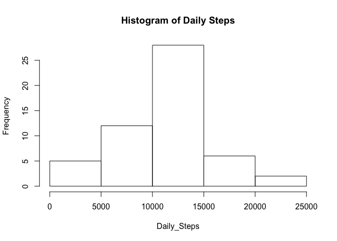

```r
hist(DailySumdf$TotalSteps, xlab="Daily_Steps", main="Histogram of Daily Steps")
```

**d**. Calculating mean and median of total steps per day

```r
mean_median_df<-DailySumdf %>% summarize(mean_steps=mean(TotalSteps), median_steps=median(TotalSteps))

xt<-xtable(mean_median_df)
print(xt, type="html", include.rownames=FALSE)
```

| mean_steps | median_steps |
| --- | --- |
| 10766.19 | 10765 |

## What is the average daily activity pattern?

**1**. Time series plot (i.e. type = “l”) of the 5-minute interval (x-axis) and the average number of steps taken, averaged across all days (y-axis)

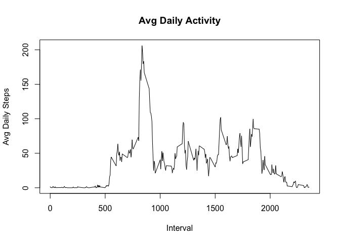

```r
avg_daily_pat_df<-cleanDF %>% group_by(interval) %>% summarize(mean_steps=mean(steps))

plot(avg_daily_pat_df$interval, avg_daily_pat_df$mean_steps, type="l",ylab="Avg Daily Steps", xlab="Interval", main="Avg Daily Activity")
```

**2**. Which 5-minute interval, on average across all the days in the dataset, contains the maximum number of steps?

- The interval is `835`.
- This can be calculated as such

```r
  filter(avg_daily_pat_df, mean_steps==max(mean_steps)) %>% select(interval)
```

```
## Source: local data frame [1 x 1]
##
##   interval
## 1      835
```

## Imputing missing values

**1**. To compute Total rows with NA’s.

- We use the original dataset `data`. then use dplyr function `filter`.

```r
naData<- filter(data, is.na(steps))
dim(naData)[1]
```

```
## [1] 2304
```

Total Rows having NAs : `2304`

**2**. In order to fill in missing (NA) values with some meaning full data, we’ll use mean steps for each of the corresponding 5-minute interval.

- The below code joins the original dataset `data` (having NA’s) to mean steps per Interval (`avg_daily_pat_df`).
- Then for the NA values, updates the “steps” variable in original dataset to the “mean_steps”.
- The final output with NA’s filled-in is stored in `data2`.

```r
data2<-left_join(data, avg_daily_pat_df, by=c("interval"="interval")) %>%
          mutate(steps=ifelse(is.na(steps), mean_steps,steps)) %>%
          select(steps, date, interval)
```

**3**. Lets calculate the mean and median of Total Steps per day for the new dataset.

```r
DailySumdf2<-data2 %>% group_by(date) %>% summarize(TotalSteps=sum(steps))

mean_median_df2<-DailySumdf2 %>% summarize(mean_steps=mean(TotalSteps), median_steps=median(TotalSteps))

xt<-xtable(mean_median_df2)
print(xt, type="html", include.rownames=FALSE)
```

| mean_steps | median_steps |
| --- | --- |
| 10766.19 | 10766.19 |

**4**. Histogram

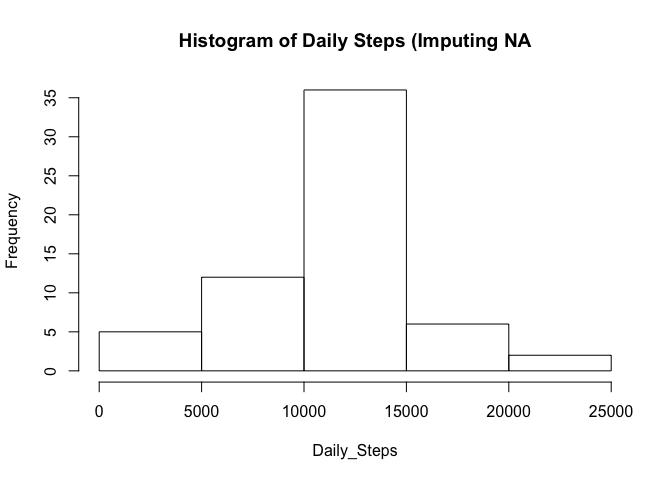

```r
hist(DailySumdf2$TotalSteps, xlab="Daily_Steps", main="Histogram of Daily Steps (Imputing NA")
```

The mean and median from previous analysis isnt much different from the mean and median after imputing the NA values.

## Are there differences in activity patterns between weekdays and weekends?

- To generate the plot we add another variable to the `data2` dataset `wkday` to indicate weekday or weekend.

```r
library(lubridate)
data2<-mutate(data2, wkday=ifelse(wday(ymd(date))==7 | wday(ymd(date))==1, "weekend","weekday"))

avg_daily_pat_df2<-data2 %>%
                  group_by(interval, wkday) %>%
                  summarize(mean_steps=mean(steps))
```

- Based on the below plot we can conclude that there is significant difference in activity levels between weekday and weekend.

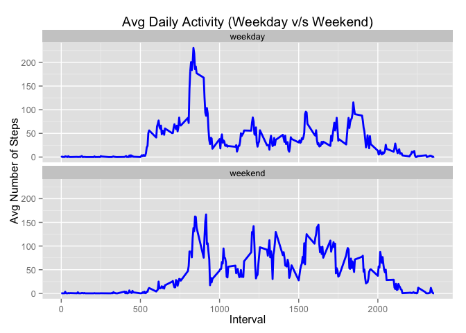

```r
library(ggplot2)
g<-ggplot(avg_daily_pat_df2, aes(interval,mean_steps)) +
    geom_line(colour="blue",size=1) +
    facet_wrap(~wkday, ncol=1) +
    labs(title="Avg Daily Activity (Weekday v/s Weekend)", x="Interval", y="Avg Number of Steps")
print(g)
```